# Introducción al Diseño de experimentos

Kevin Palomino

2024-01-26

El diseño de experimentos es una metodología fundamental en la investigación científica que busca establecer relaciones causales entre variables. Al planificar y ejecutar un experimento, se pretende controlar y manipular las condiciones bajo las cuales ocurren los fenómenos de interés, con el fin de obtener conclusiones válidas y confiables. A través de la adecuada selección y disposición de las variables, así como la aplicación de técnicas estadísticas apropiadas, el diseño experimental permite explorar y entender de manera sistemática el comportamiento de los sistemas estudiados. En este contexto, la precisión en la formulación y ejecución del diseño es esencial para garantizar la validez y la generalización de los resultados obtenidos.ß

# Contenido

1. ¿Qué es el Diseño de Experimentos (DOE)?
2. Conceptos básicos.
3. Principios básicos.
4. Etapas del Diseño de Experimentos.
5. Repaso

# 1. ¿Qué es el Diseño de Experimentos (DOE)?

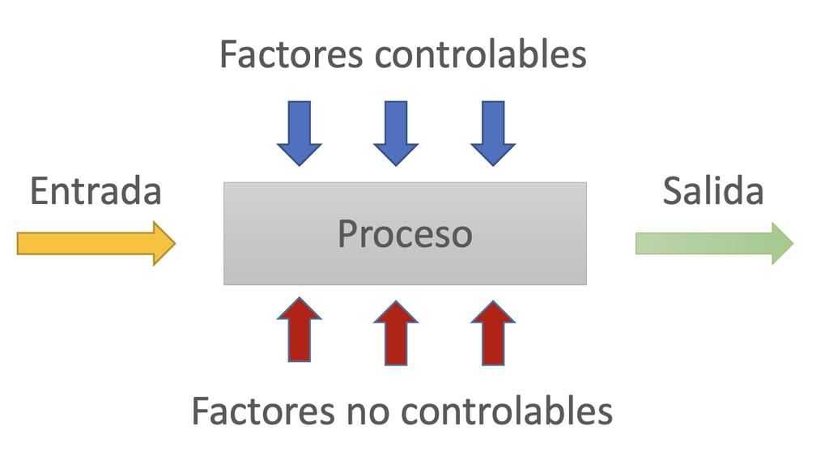

## 1.1 Objetivos del Diseño de Experimentos

- *Relevancia*: Determinarr los factores significativos
- *Optimización*: Fijar condiciones de operación
- *Variabilidad*: Diseñar un proceso robusto
- *Modelación*: Construir modelos de regresión

# 2. Conceptos básicos

- *Experimento*: Cambio en las condiciones de operación de un sistema con el objetivo de medir el efecto de dicho cambio en la respuesta.
- *Unidad experimental*: Pieza(s) o muestra(s) que se utiliza para generar una medición de la respuesta.
- *Variable de respuesta*: Variable a optimizar y que depende potencialmente de los factores. No es controlada por el experimentador.
- *Factores*: Fenómenos que potencialmente causan variación y que se pueden fijar en un valor dado.
- *Niveles de factores*: Valores que un factor puede tomar. Pueden ser categóricos o numéricos.
- *Tratamiento*: Combinación de niveles de todos los factores involucrados en el experimento.
- *Iteracción*: Impacto en la respuesta por el cambio de un factor influido por la presencia de otro.
- *Corrida experimental*: Cada ejecución del experimento bajo un tratamiento para tener una medición de la variable de respuesta.
- *Réplica*: Todas las corridas experimentales con la misma combinación de niveles (tratamientos).
- *Experimento balanceado*: Experimento en que todos los niveles de cada factor aparece el mismo número de veces en las corridas.
- *Error aleatorio*: Variabilidad de la respuesta que no está explicada por los factores del experimento.

# 3. Principios básicos

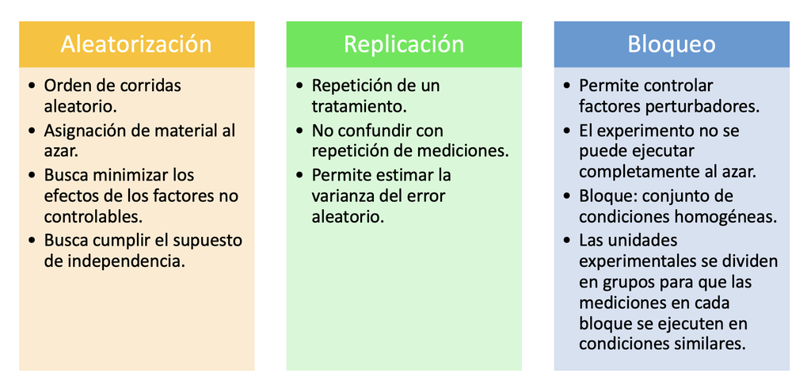

# 4. Etapas del Diseño de Experimentos

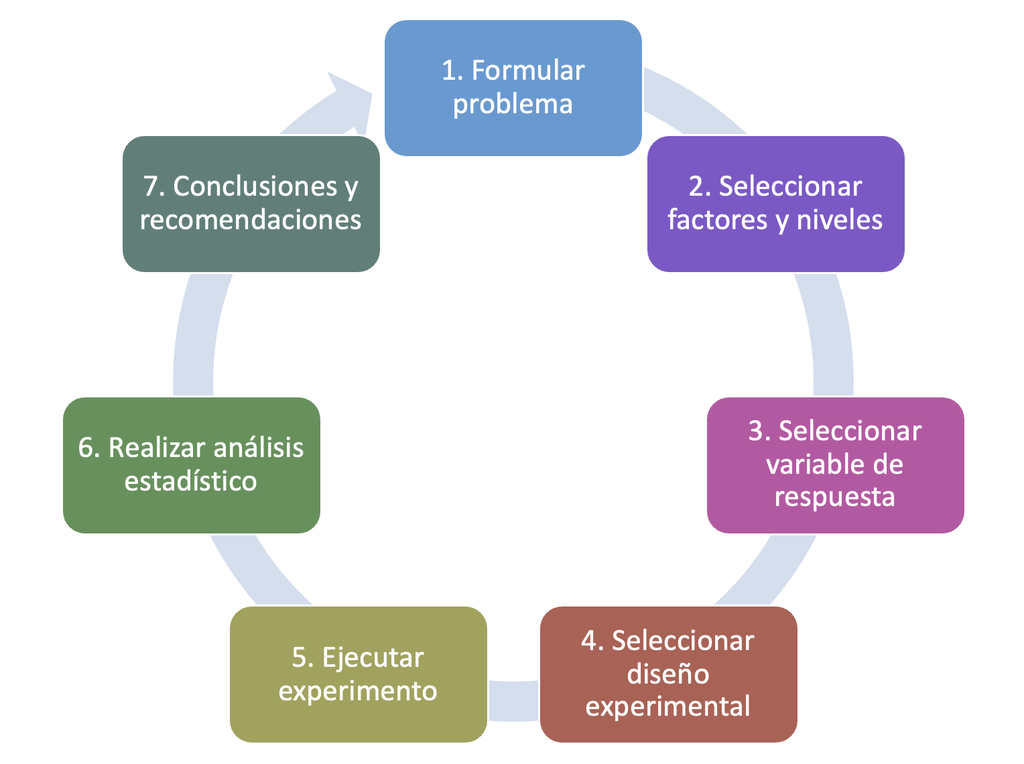

# 5. Repaso:

## 5.1 Distribución de probabilidades

### 5.1.1 Muestras grandes

Sea $\overline{x}$ la media de una muestra aleatoria de tamaño n selecionada de una población con media $\mu$ y varianza $\sigma^2>0$. Supongamos que se cumple alguna de las siguientes condiciones:

1. La población es normal y $\sigma^2$ es conocida (No importa el tamaño de n).
2. La población es normal y $\sigma^2$ es desconocida y $n\geq30$.
3. La forma de La población es desconocida (o no normal), $\sigma^2$ es conocida o desconocida y $n\geq30$.

Entonces, la distribución muestral de la media muestral $\overline{x}$ es normal con media $\mu_{\overline{x}}$ y varianza $\sigma_{\overline{x}}^2$, calculadas a partir de la siguiente formula:

$$Z=\frac{\overline{x}-\mu_{\overline{x}}}{\sigma_{\overline{x}}}$$

### 5.1.2 Muestras pequeñas

Si el muestro se hace en una población normal con varianza desconocida y si las muestras seleccionadas son de tamaño $n < 30$, entonces, la distribución muestral de la media muestral $\overline{x}$ es la de $t$ de $Student$ con $n-1$ grados de libertad. Por lo tanto, se utiliza la siguiente expresión:

$$t =
\frac{\overline{x}-\mu_{\overline{x}}}{\sigma_{\overline{x}}}$$

*Resumen*

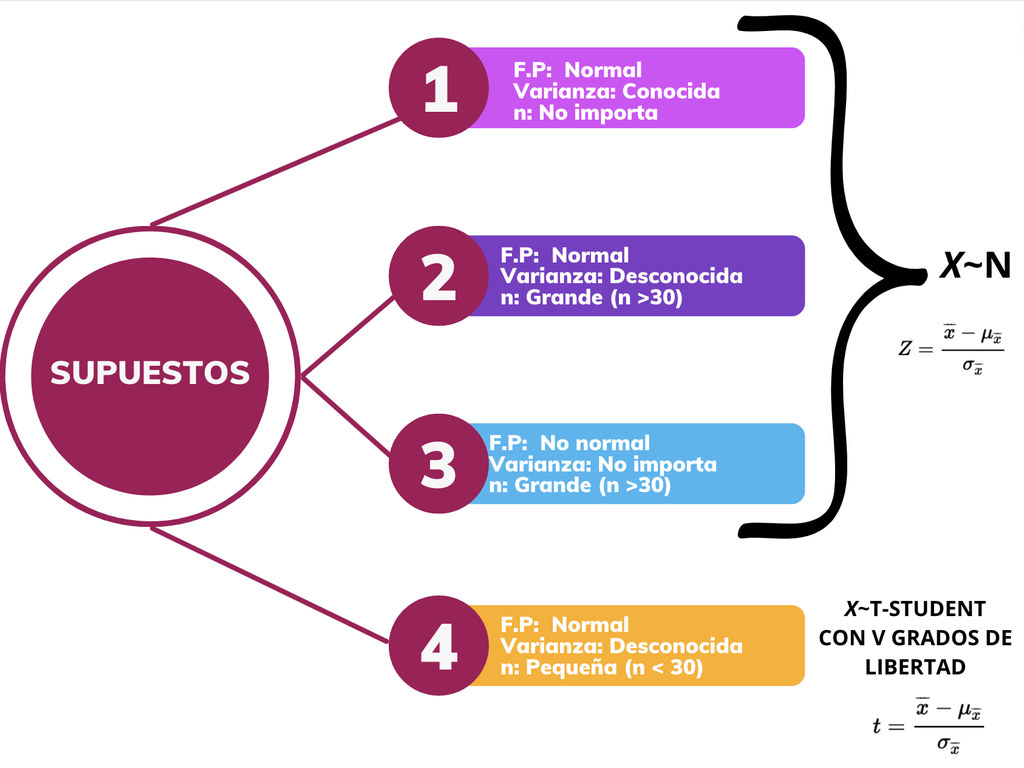

*Algunas observaciones para la media varianza muestrales*

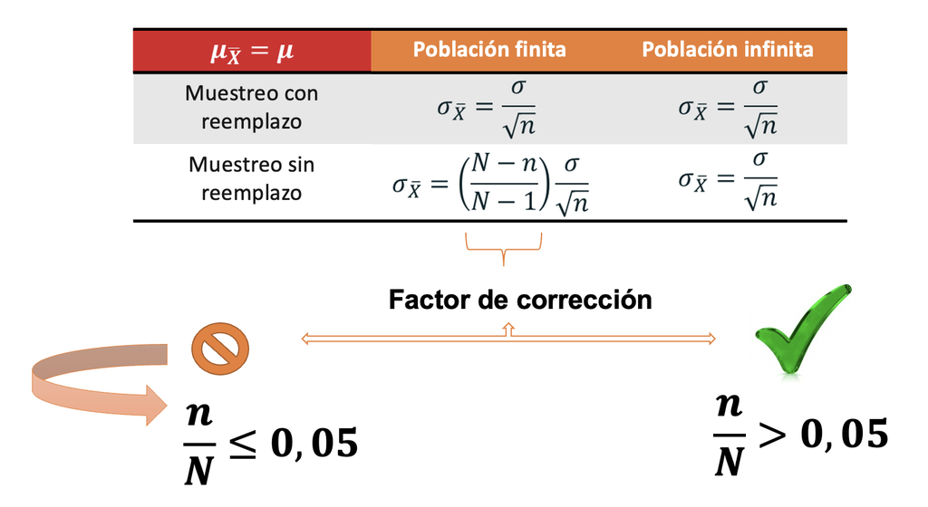

### 5.1.3 Ejemplos

Antes de iniciar a revolver algunos ejemplos, les presento algunas funciones utiles para obtener los graficas y las probabilidades

```r
## Funciones para graficar la probabilidad
normal_area <- function(mean = 0, sd = 1, lb, ub, acolor = "lightgray", ...) {
  x <- seq(mean - 3 * sd, mean + 3 * sd, length = 100)
  if (missing(lb)) {
    lb <- min(x)
  }
  if (missing(ub)) {
    ub <- max(x)
  }
  x2 <- seq(lb, ub, length = 100)
  plot(x, dnorm(x, mean, sd), type = "n", ylab = "")
  y <- dnorm(x2, mean, sd)
  polygon(c(lb, x2, ub), c(0, y, 0), col = acolor)
  lines(x, dnorm(x, mean, sd), type = "l", ...)
}

## Funcion para t-stundet
ts<-function(x,media,sd){
  (x-media)/sd
}
```

#### 5.1.3.1 Ejemplo 1

Suponga que el incremento porcentual de los salarios de los funcionarios de todas las corporaciones medianas se distribuye siguiendo una distribución normal con media 12.2% y desviación típica 3.6%. Si se toma una muestra aleatoria de nueve observaciones de esta población según los incrementos porcentuales de salario, ¿cuál es la probabilidad de que la media muestra sea mayor que 10%?

**Datos**

Media poblacional: 12.2

Desviación poblacional: 3.6

n: 9

Distribución: Normal

**Solución**

- **Paso 1**: revisamos los supuestos, esto es:
- La distribución de probabilidad es normal? : **Si**
- La varianza poblacional es conocida? : **Si**
- El tamaño de la muestra es grande: **No**

Por lo tanto, suponemos que $\overline{x}$ se distribuye con una distribución normal con

$$Z=\frac{\overline{x}-\mu_{\overline{x}}}{\sigma_{\overline{x}}}$$

- **Paso 2**: Construimos la probabilidad solicitada, esto es:

$$P(X>10)$$

- **Paso 3**: Usamos las funciones declaradas anteriormente, y el siguiente código:

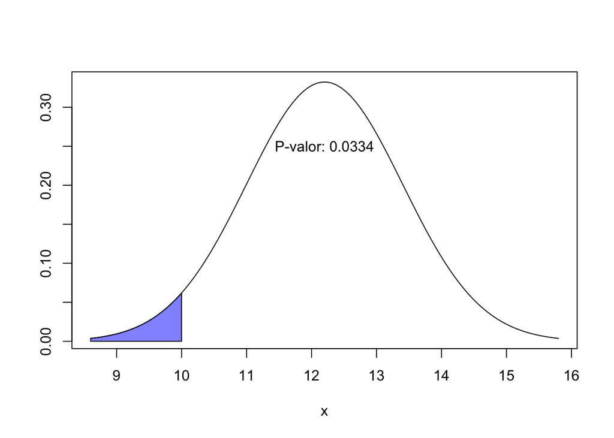

```r
#Ejemplo 1

media=12.2 # Ingresar dato
desviacion=3.6/sqrt(9) # Ingresar dato
ValorProb =10 # Ingresar dato

#####################################################################

prob=pnorm( ValorProb, media, desviacion, lower.tail = TRUE)
normal_area(mean = media, sd = desviacion, ub =ValorProb , acolor = rgb(0, 0, 1, alpha = 0.5))
y_coor=pnorm(media, media, desviacion, lower.tail = TRUE)/2
text(x = media, y = y_coor,label = paste0("P-valor: ",round(prob,4)))
```

- **Paso 4:** Presetamos el resultado

Como la función declarada siempre arroja la $P(X<x_0)$, entonces, si deseamos encontrar el resultado para este ejemplo en particular, debemos calcular el complemento de esta probabilidad, esto es:

$$P(X>x_0) = 1-
P(X<x_0)$$

Por lo tanto, la probabilidad de que la media muestra sea mayor que 10% es:

$$P(X>10) = 1- P(X<10)$$
$$P(X>10) = 1- 0.0334$$
$$P(X>10) = 0.9666$$

#### 5.1.3.2 Ejemplo 2

Suponga que de una población normal con media 20 se toma una muestra de 16. Si la desviación estándar muestral es 4, encuentre la probabilidad de que la media muestra sea estrictamente menor que 21.735.

**Datos**

Media muestral: 20

Desviación: 4

n: 16

Distribución: Normal

**Solución**

- **Paso 1**: revisamos los supuestos, esto es:
- La distribución de probabilidad es normal? : **Si**
- La varianza poblacional es conocida? : **No**
- El tamaño de la muestra es grande: **No**

Por lo tanto, suponemos que $\overline{x}$ se distribuye con una t-student con $n-1$ grados de libertad:

$$t =
\frac{\overline{x}-\mu_{\overline{x}}}{\sigma_{\overline{x}}}$$
- **Paso 2**: Construimos la probabilidad solicitada, esto es:

$$P(X<21.735)$$

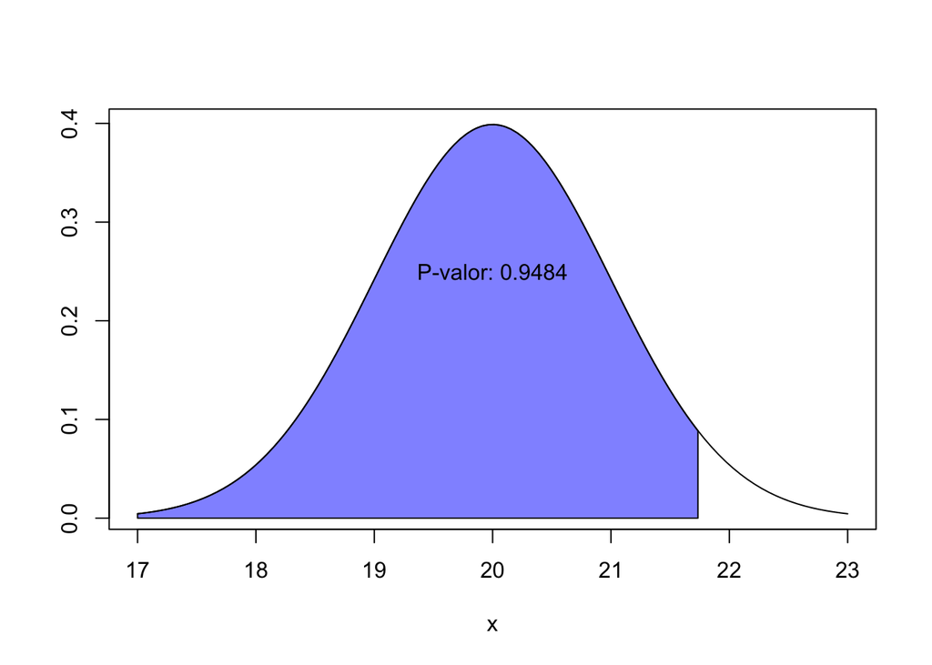

```r
#Ejemplo 2

media=20 # Ingresar dato
desviacion=4/sqrt(16) # Ingresar dato
ValorProb =21.735 # Ingresar dato
Grados_libertad= 16-1 #Ingresar dato


#####################################################################
prob=pt(ts(ValorProb,media,desviacion),Grados_libertad,lower.tail = TRUE)
normal_area(mean = media, sd = desviacion, ub =ValorProb , acolor = rgb(0, 0, 1, alpha = 0.5))
y_coor=pt(ts(media,media,desviacion),Grados_libertad,lower.tail = TRUE)/2
text(x = media, y = y_coor,label = paste0("P-valor: ",round(prob,4)))
```

- **Paso 4:** Presetamos el resultado

#### 5.1.3.3 Ejercicios propuestos

- Un fabricante declara que la duración de las bujías que el fabrica sigue una distribución normal con una media de 36000 kilómetros y una desviación estándar de 4000 kilómetros. Para una muestra aleatoria de dieciséis bujías, se obtuvo una duración media de 34500 km. Si a afirmación del fabricante es correcta, ¿ cuál es la probabilidad de obtener una media muestral tan pequeña como esta o menor?
- Un estudio de tránsito revela que el numero promedio de ocupantes de un auto es 1.75. En una muestra de 50 autos con desviación estándar 0.65, seleccionada de una población norma, encuentre la probabilidad de que un numero promedio de ocupante sea mayor que 2.
- Una muestra aleatoria de seis autos de un determinado modelo evidencia que cada uno de ellos consume las siguientes cantidades en kilómetros por litro:

  ```
                          18.6     18.4    19.2     20.8    19.4      20.5
  ```

  Determine la probabilidad de que el consumo de gasolina medio muestral de automóviles sea menor que 17.6km por litro, suponiendo que la distribución de la población es normal con media 17.
- En una fábrica de chocolates llamada “Sweet Delights”, el equipo de calidad está llevando a cabo un estudio sobre el peso de las barras de chocolate producidas en una máquina específica. El equipo está interesado en determinar la distribución del peso medio de las barras de chocolate tomadas de muestras aleatorias de la producción diaria. Se sabe que el peso de las barras de chocolate sigue una distribución normal con una media poblacional de 100 gramos y una desviación estándar poblacional de 5 gramos. Supongamos que el equipo de calidad ha tomado una muestra aleatoria de 25 barras de chocolate hoy. Calcule la probabilidad de que el peso medio de estas barras de chocolate esté entre 98 y 102 gramos.

## 5.2 Distribución muestral de la diferencia de medias

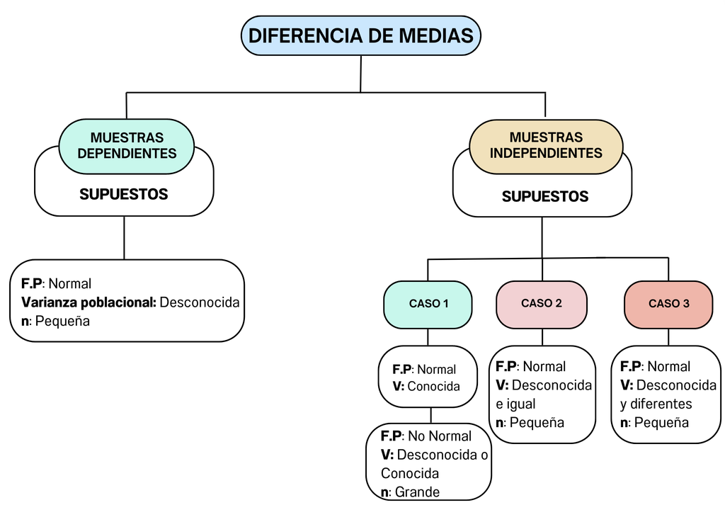

### 5.2.1 Muestras Dependientes (Pareadas)

De manera general, si se toma una muestra aleataoria de $n$ pares de observaciones representradas por $(x_1,y_1), (x_2,y_2), ... , (x_n,y_n)$,procedentes de dos poblaciones con medias $\mu_1$ y $\mu_2$. De modo que,$x_1, x_2, ... , x_n$ corresponden a las observaciones muestrales de una población con media $\mu_1$ mientras que $y_1, y_2, ... , y_n$ corresponden a las observaciones muestrales de una población con media $\mu_2$.

Ahora bien, si $d_i= x_i-y_i$, para cada $i=1,...,n$, entonces, la diferencias $d_1, d_2, ... d_n$ se pueden pensar como una muestra aleatoria de la población de diferencias de datos pareados. Con esto tenemos que si $\overline{x}$y $\overline{y}$ son las medias muestrales $x_1, x_2, ... , x_n$ y $y_1, y_2, ... , y_n$, entonces,la media $\overline{d}$ de las diferencias muestrales viene dada por $\overline{d}=\overline{x}-\overline{y}$ con lo cual lo podemos asociar con un estadístico $\overline{D}$, definido como la diferencia de medias muestrales $\overline{D}=\overline{X}-\overline{Y}$.

En este sentido la media y varianza que se utilizan en este casos son:

| Estadístico | Media | Varianza |
| --- | --- | --- |
| $\overline{D}=\overline{X}-\overline{Y}$ | $\mu_{\overline{D}}= \mu_1-\mu_2$ | $\sigma_{\overline{D}}^2=\frac{s_{d}^2}{n}$ |

Por lo tanto, la distribución muestral de $\overline{D}$ es la $t$ de Student con $n-1$ grados de libertad. Su expresión esta dada por:

$$t=\frac{\overline{D}-\mu_{\overline{D}}}{\sigma_{\overline{D}}}$$

#### 5.2.1.1 Ejemplo 3

Se recoge datos de consumo de gasolina correspondiente a una muestra aleatoria de 8 automoviles colombianos de dos modelos diferentes. Se forman pares con las dos muestras y cada elemento de un determinado par fue conducido por la misma ruta y por el mismo piloto.

| $x_i$ (auto A) | 19.4 | 18.8 | 20.6 | 17.6 | 19.2 | 20.9 | 18.3 | 20.4 |
| --- | --- | --- | --- | --- | --- | --- | --- | --- |
| $y_i$ (auto B) | 19.6 | 17.5 | 18.4 | 17.5 | 18.0 | 20.0 | 18.8 | 19.2 |

**Solución**

Empezamos por calcular la direncia entre las muestras pareadas, esto es:

```r
#Ejemplo 3

xi=c(19.4,18.8,20.6,17.6,19.2,20.9,18.3,20.4)
yi=c(19.6,17.5,18.4,17.5,18.0,20.0,18.8,19.2)


#diferencia de muestras
d=xi-yi
d
```

```
## [1] -0.2  1.3  2.2  0.1  1.2  0.9 -0.5  1.2
```

Segundo, calculamos la media de las diferencias, esto es:

$$\overline{d}= \frac{d_1+ ... +
d_n}{n}$$

```r
#promedio

dprom=mean(d)
dprom
```

```
## [1] 0.775
```

Tercero, Calculamos la desviación, esto es:

$$s_d= \sqrt{\frac{\sum (d_i-
\overline{d})^2}{n-1}}$$

```r
#Desviación

ddes=sd(d)
ddes
```

```
## [1] 0.9035644
```

$$\sigma_{\overline{D}}=\frac{s_d}{\sqrt{n}}$$
Reemplazando los datos, tenemos que:

```r
#Desviación

dm=ddes/sqrt(8)
dm
```

```
## [1] 0.3194582
```

Entonces, encontramos que,

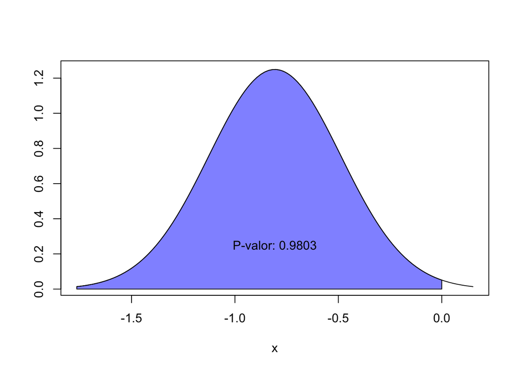

```r
#Ejemplo 2

media=-0.807 # Ingresar dato
desviacion=0.903/sqrt(8) # Ingresar dato
ValorProb =0 # Ingresar dato
Grados_libertad= 8-1 #Ingresar dato


#####################################################################
prob=pt(ts(ValorProb,media,desviacion),Grados_libertad,lower.tail = TRUE)
normal_area(mean = media, sd = desviacion, ub =ValorProb , acolor = rgb(0, 0, 1, alpha = 0.5))
y_coor=pt(ts(media,media,desviacion),Grados_libertad,lower.tail = TRUE)/2
text(x = media, y = y_coor,label = paste0("P-valor: ",round(prob,4)))
```

Por lo tanto, la probabilidad de que el consumo promedio de gasolina del auto A sea mayor que el auto B es aproximadamente 0.02.

#### 5.2.1.2 Ejercicios propuestos

- En una línea de producción de alimentos envasados, se están evaluando dos métodos de sellado para bolsas de snacks. Se toma una muestra de 15 bolsas y se sella cada bolsa utilizando ambos métodos en diferentes partes de la bolsa. Después de realizar pruebas de integridad del sellado, se registra el número de bolsas que presentan fugas en cada método. Calcular la probabilidad de que la diferencia media en el número de bolsas con fugas entre los métodos de sellado sea menor que 1 bolsa. Supongamos que la diferencia media poblacional en el número de bolsas con fugas es de $\mu_{\overline{D}}=0.8$.

| M1 | 1.65 | 0.78 | 0.36 | 0.09 | 0.94 | 1.26 | 0.71 | 0.87 | 1.13 | 1.21 | 1.03 | 1.04 | 1.46 | 0.20 | 0.71 |
| --- | --- | --- | --- | --- | --- | --- | --- | --- | --- | --- | --- | --- | --- | --- | --- |
| M2 | 0.99 | 1.64 | 0.93 | 0.65 | 0.93 | 0.44 | 1.08 | 1.45 | 1.23 | 1.14 | 0.31 | 0.85 | 0.69 | 1.04 | 0.41 |

- En una planta de producción de productos químicos, se están comparando dos métodos de fabricación para un nuevo producto. Se toma una muestra de 12 lotes de productos fabricados utilizando cada método. Después de realizar pruebas de calidad, se registra la concentración promedio de un componente clave en cada lote. Calcular la probabilidad de que la diferencia media en la concentración de componente clave entre los lotes fabricados con el primer método y los fabricados con el segundo método sea mayor que 0.1%. Supongamos que la diferencia media en la concentración del componente clave es de $\mu_{\overline{D}}=0.05\%$.

  | L1 | 0.09 | 0.04 | 0.08 | 0.07 | 0.03 | 0.07 | 0.07 | 0.04 | 0.03 | 0.09 | 0.04 | 0.07 |
  | --- | --- | --- | --- | --- | --- | --- | --- | --- | --- | --- | --- | --- |
  | L2 | 0.06 | 0.07 | 0.05 | 0.08 | 0.08 | 0.05 | 0.02 | 0.05 | 0.05 | 0.03 | 0.08 | 0.05 |

### 5.2.1 Muestras independientes

Consideremos dos poblaciones de $\mu_1$ y $\mu_2$ y varianzas $\sigma_1^2$ y $\sigma_2^2$ representativas, luego se selecciona dos muestras aleatorias independientes de tamaño $n_1$ y $n_2$, con medias $\overline{x}_1$ y $\overline{x}_2$ y varianzas $s_1^2$ y $s_2^2$. Entonces, se consiste en determinar la distribución muestral de $\overline{X}_1-\overline{X}_2$. Para lo cual se siguen los siguientes casos:

- Las varianzas poblacionales son conocidas o desconocidas, pero las muestras son grandes.
- las varianzas poblacionales son desconocidas, pero iguales, y las muestras son pequeñas.
- Las varianzas poblacionales son desconocidas, pero diferentes, y las muestras son pequeñas.

#### 5.2.1.1 Caso 1: Varianzas poblacionales conocidas o desconocidas y muestras grandes.

Para este caso, se deben cumplir algunas de estas condiciones:

- Ambas poblaciones son normales y ambas varianzas poblacionales $\sigma_1^2$ y $\sigma_2^2$ son conocidas.
- Ambas poblaciones son desconocidas o no normales, ambas varianzas poblacionales $\sigma_1^2$ y $\sigma_2^2$ son conocidas o desconocidas y $n_1 \ge 30$ y $n_2 \ge 30$.

Entonces la distribución de muestral del diferencia entre dos medias muestrales estará distribuida normalmente y se utiliza la siguiente formula:

$$Z=
\frac{(\overline{x}_1-\overline{x}_2)-(\mu_1-\mu_2)}{\sqrt{\frac{\sigma_1^2}{n_1}+\frac{\sigma_2^2}{n_2}}}$$

#### 5.2.1.2 Caso 2: Varianzas poblacionales desconocidas, iguales y muestras pequeñas.

Si $\sigma_1^2$ y $\sigma_2^2$ son iguales y desconocidas, además, las poblaciones son normales y los tamaños de muestras son pequeños, entonces se utiliza la siguiente formula:

$$t=
\frac{(\overline{x}_1-\overline{x}_2)-(\mu_1-\mu_2)}{\sqrt{\frac{s^2}{n_1}+\frac{s^2}{n_2}}}$$

Donde la varianza muestral combinada esta dada por:

$$s^2=
\frac{(n_1-1)s_1^2+(n_2-1)s_2^2}{n_1+n_2-2}$$

Distribuida según la distribución t-student con $n_1+n_2-2$ grados de libertad.

#### 5.2.1.3 Caso 3: Varianzas poblacionales desconocidas, diferentes y muestras pequeñas.

Si $\sigma_1^2$ y $\sigma_2^2$ son diferentes y desconocidas, además, las poblaciones son normales y los tamaños de muestras son pequeños, entonces se utiliza la siguiente formula:

$$t=
\frac{(\overline{x}_1-\overline{x}_2)-(\mu_1-\mu_2)}{\sqrt{\frac{s_1^2}{n_1}+\frac{s_2^2}{n_2}}}$$
Distribuida según la distribución t-student con

$$\nu =
\frac{(\frac{s_1^2}{n_1}+\frac{s_2^2}{n_2})^2}{\frac{s_1^2/n_1}{n_1-1}+\frac{s_2^2/n_2}{n_2-1}}$$

grados de libertad. Y, dado que. $\nu$ rara vez es un entero, se redondea al entero mas cercano.

#### 5.2.1.4 Ejemplo 4

Se lleva a cabo dos experimentos independientes en los que se comparan dos tipos de impresoras. Se imprimen, para el caso, 18 hojas con el tipo A y se registra el tiempo de secado en minutos de cada una. Lo mismo se hace con el tipo B. Se sabe que la desviación de la población es 1 en ambas. Suponga que el tiempo medio de secado es igual para los dos tipos de impresoras y encuentre $P(\overline{X}_A-\overline{X}_B> 1)$, donde $\overline{X}_A$ y $\overline{X}_B$ son los tiempos promedios de secado para las muestras de tamaño $n_A = n_B =18$. Suponga que las poblaciones son normales.

**Datos**

$n_1=n_2=18$

$\sigma_1=\sigma_2= 1$

$\mu_1=\mu_2$

**Paso 1**: revisamos los supuestos, esto es:

- La distribución poblacional es normal? : **Si**
- Las varianzas poblacionales son conocidas? : **Si**
- Las varianzas poblacionales son iguales? : **Si**
- El tamaño de la muestra es grande: **No**

Por lo tanto, suponemos que $\overline{X}_A-\overline{X}_B$ se distribuye con una distribución normal con

$$Z=
\frac{(\overline{x}_1-\overline{x}_2)-(\mu_1-\mu_2)}{\sqrt{\frac{\sigma_1^2}{n_1}+\frac{\sigma_2^2}{n_2}}}$$

**Paso 2**: Construimos la probabilidad solicitada, esto es:

$$P(\overline{X}_A-\overline{X}_B>
1)$$

**Paso 3**: Resolvemos la probabilidad

1. Matemáticamente

$$P(\overline{X}_A-\overline{X}_B> 1) =
1-P(\overline{X}_A-\overline{X}_B< 1)$$
$$=
1-P(Z<\frac{(\overline{x}_1-\overline{x}_2)-(\mu_1-\mu_2)}{\sqrt{\frac{\sigma_1^2}{n_1}+\frac{\sigma_2^2}{n_2}}})$$

Ahora si reemplazando los datos, obtenemos:

$$=
1-P(Z<\frac{(1)-(0)}{\sqrt{\frac{1^2}{18}+\frac{1^2}{18}}})$$
$$= 1-P(Z<3)=1-0.9987=0.0013$$

2. Usando R

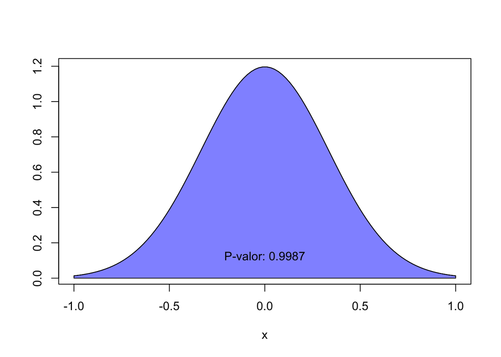

```r
#Ejemplo 4

media1=0 # Ingresar dato
media2=0 # Ingresar dato
desviacion1=1 # Ingresar dato
desviacion2=1 # Ingresar dato
ValorProb =1 # Ingresar dato
n1= 18# Ingresar dato
n2= 18 # Ingresar dato

#####################################################################

desviacion=sqrt(desviacion1^2/n1+desviacion2^2/n2)
prob=pnorm( ValorProb, media1-media2, desviacion, lower.tail = TRUE)
normal_area(mean = media1-media2, sd = desviacion, ub =ValorProb , acolor = rgb(0, 0, 1, alpha = 0.5))
y_coor=pnorm(media1-media2, media1-media2, desviacion, lower.tail = TRUE)/4
text(x = media1-media2, y = y_coor,label = paste0("P-valor: ",round(prob,4)))
```

Recodemos que el codigo entrega la respuesta acumulada a la izquierda y el interronte del ejercicio nos pide el acomulado hacia a la derecha, por lo tanto,

$$P(\overline{X}_A-\overline{X}_B>
1)=1-0.9987 = 0.0013$$

**Paso 4**: Presentamos la respuesta

La probablidad de que la diferencia del tiempo de secado de las impresora A y B sea mayor que 1 es $0.13\%$

#### 5.2.1.5 Ejemplo 5

Suponga que dos drogas A y B de las que se dice que reducen el tiempo de respuesta de las ratas a determinado estimulo, se están comparando en un experimento de laboratorio. El experimentador sabe que en las respectivas poblaciones los tiempos de respuestas al estimulo están distribuidos normalmente. Se administra que la droga A a 12 ratas y B a 13 ratas. Cuando se lleva a cabo el experimento de reducción de promedio de tiempo de respuesta al estimulo por parte de las ratas que están recibiendo la droga A es 30,45 con una desviación típica de 5 milisegundos. Los datos correspondientes a las droga B son 24,9 y 6 milisegundos ¿Cuál es la probabilidad de que la diferencia entre la reducción promedio de respuesta al estimulo por parte de las ratas que están recibiendo la droga A y de las ratas que están recibiendo la droga B sea menor o igual a la observada en el experimento? Suponga que no hay diferencia alguna entre las dos drogas con respecto a la reducción promedio en tiempos de respuestas y que las drogas son igualmente efectivas. suponga que las varianzas poblacionales son iguales.

**Datos**

$n_1=12$

$n_2=13$

$s_1=5$

$s_2=6$

$\mu_1=\mu_2$

$\overline{x}_1=30.45$

$\overline{x}_2=24.9$

**Paso 1**: revisamos los supuestos, esto es:

Por lo tanto, suponemos que $\overline{X}_A-\overline{X}_B$ se distribuye con una distribución normal con

$$t=
\frac{(\overline{x}_1-\overline{x}_2)-(\mu_1-\mu_2)}{\sqrt{\frac{s^2}{n_1}+\frac{s^2}{n_2}}}$$

Donde la varianza muestral combinada esta dada por:

$$s^2=
\frac{(n_1-1)s_1^2+(n_2-1)s_2^2}{n_1+n_2-2}$$

Y gardos de libertad $n_1+n_2-2$.

**Paso 2**: Construimos la probabilidad solicitada, esto es:

$$P(\overline{X}_A-\overline{X}_B \le
30.45-24.9=5.55)$$

**Paso 3**: Resolvemos la probabilidad

1. Matemáticamente

Primero, debemos encontrar la varianza muestral combinada, esto es:

$$s^2=
\frac{(n_1-1)s_1^2+(n_2-1)s_2^2}{n_1+n_2-2}=
\frac{(12-1)5^2+(13-1)6^2}{12+13-2}=30.74$$
Segundo, desarrollamos la probabilidad

$$P(\overline{X}_A-\overline{X}_B \le
5.55) = 1-P(t>
\frac{(\overline{x}_1-\overline{x}_2)-(\mu_1-\mu_2)}{\sqrt{\frac{s^2}{n_1}+\frac{s^2}{n_2}}})$$

$$= 1-P(t>
\frac{(5.55)-(0)}{\sqrt{\frac{30.74}{12}+\frac{30.74}{13}}})$$
$$= 1-P(t> 2.5)$$
Ahora bien, los grados de libertad son $n_1+n_2-2=12=13-2=23$, el valor de tabla obtenido es 0.01:

$$P(\overline{X}_A-\overline{X}_B \le
5.55) = 1-0.01 =0.99$$

2. Usando R

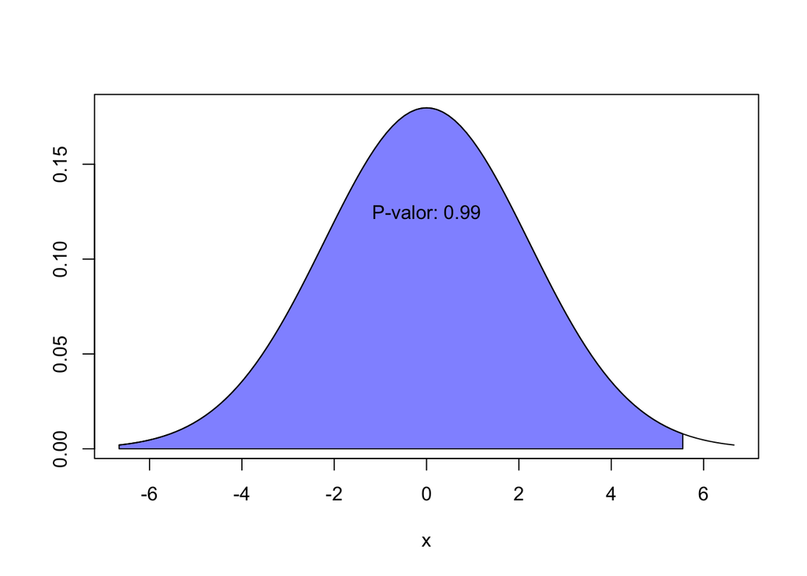

```r
#Ejemplo 4

media1=0 # Ingresar dato
media2=0 # Ingresar dato
desviacion1=5 # Ingresar dato
desviacion2=6 # Ingresar dato
ValorProb =5.55 # Ingresar dato
n1= 12# Ingresar dato
n2= 13 # Ingresar dato

#####################################################################
Grados_libertad=n1+n2-2
s_cua=((n1-1)*desviacion1^2+(n2-1)*desviacion2^2)/(n1+n2-2)
desviacion=sqrt(s_cua/n1+s_cua/n2)
prob=pt(ts(ValorProb,media1-media2,desviacion),Grados_libertad,lower.tail = TRUE)
normal_area(mean = media1-media2, sd = desviacion, ub =ValorProb , acolor = rgb(0, 0, 1, alpha = 0.5))
y_coor=pt(ts(media1-media2,media1-media2,desviacion),Grados_libertad,lower.tail = TRUE)/4
text(x = media1-media2, y = y_coor,label = paste0("P-valor: ",round(prob,4)))
```

Recodemos que el codigo entrega la respuesta acumulada a la izquierda ypor lo tanto, la respuesta es 0.99001.

**Paso 4**: Presentamos la respuesta

La probabilidad de que la diferencia entre la reducción promedio de respuesta al estimulo por parte de las ratas que están recibiendo la droga A y de las ratas que están recibiendo la droga B sea menor o igual a la observada en el experimento es $99\%$.

#### 5.2.1.6 Ejercicios propuestos

- Las baterías del fabricante A tienen una duración media de 6.5 años y una desviación típica de 0.9 años, mientras que las del fabricante B tienen una duración media de 6.0 años y una varianza de 0.64 años. Asumiendo que los datos provienen de una distribución normal ¿Cuál es la probabilidad de que una muestra aleatoria de 18 baterías del fabricante A tengan una duración media que sea a lo sumo de dos años más que la duración media de una muestra de 22 baterías del fabricante B?
- Suponga que cuando el pH de cierto compuesto químico es 5, el pH medido por un estudiante de quimica, seleccionado al azar en una jornada matutina, es una variable aleatoria con distribución normal con media 5 y desviación estándar 0.2.Luego, un lote grande del compuesto se subdivide y se da una muestra a cada estudiante de un laboratorio vispertino. Sea $\overline{X}$ el pH promedio medido por los alumnos de la mañana y $\overline{Y}$ el pH promedio medido por los alumnos de la tarde.
1. Si el ph es una variable normal y hay 25 estudiantes en cada laboratorio, calcule $P(-0.1 \le \overline{X}-\overline{Y} \le 0.1)$
2. Si hay 36 estudiantes en cada laboratorio, pero las determinaciones del ph no se suponen normales, calcule $P(-0.1 \le \overline{X}-\overline{Y} \le 0.1)$
- Suponga que la duración esperada para una batería de tipo A es 150 horas y la desviación estándar es 8 horas. Para otra batería de tipo B, Suponga que laduración esperada y desviación estándar son respectivamente 100 y 6 horas. Sea $\overline{X}$ la duración promedio de una muestra aleatoria de 40 baterías de tipo A y sea $\overline{Y}$ la duración promedio de una muestra aleatoria de 35 baterías de tipo B. Calcule $P(148 \le \overline{X}-\overline{Y} \le 154)$

## 5.3 Intervalos de confiaza para la media poblacional

### 5.3.1 Caso para muestras grandes

Supongamos que tenemos una muestra aleatoria de una distribución con media desconocida. El objetivo del intervalo de confianza es hallar un rango de valores para la media poblacional solo si se cumplen los siguientes supuestos:

- La población es normal con varianza ($\sigma^2$) conocida. No importa el tamaño de la muestra.
- La población es normal con varianza ($\sigma^2$) desconocida y el tamaño de la muestra es grande ($n \ge 30$).
- La forma de la población es no normal, su varianza ($\sigma^2$) es conocida o desconocida y el tamaño de la muestra es grande ($n \ge 30$).

Entonces, el intervalo de confianza de $(1-\alpha)$ para $\mu$ es:

### 5.3.2 Caso para muestras pequeñas

Este caso es cuando la población es normal y la varianza ($\sigma^2$) poblacional es desconocida y el tamaño de la muestra es pequena ($n \le 30$). Entonces, el intervalo de confianza de $(1-\alpha)$ para $\mu$ es:

$$\overline{x}-t_{\alpha/2}\frac{s}{\sqrt{n}} \le
\mu\le \overline{x}+t_{\alpha/2}\frac{s}{\sqrt{n}}$$

Con $n-1$ grados de libertad.

### 5.3.3 Ejemplo 6

Un fabricante produce bolsas de arroz. El peso del contenido de estas bolsas tiene una distribución normal con desviación típica 15 gramos. A su vez, los contenidos de una muestra aleatoria de 25 bolsas tienen un peso medio de 100 gramos. Calcúlese un intervalo de confianza del 95% para el verdadero peso medio de todas las bolsas de arroz producidas por el fabricante.

**Datos** Desviación poblacional ($\sigma$) = 15

n = 25

Nivel de confianza = 95%

Media muestral ($\overline{x}$) = 100

**Paso 1**: revisamos los supuestos, esto es:

- La distribución poblacional es normal? : **Si**
- La varianza poblacional es conocida? : **Si**
- El tamaño de la muestra es grande: **No**

Por lo tanto, el el intervalo de nivel confianza de 95% para $\mu$ es:

$$\overline{x}-Z_{\alpha/2}\frac{\sigma}{\sqrt{n}}
\le \mu\le \overline{x}+Z_{\alpha/2}\frac{\sigma}{\sqrt{n}}$$
**Paso 2**: Resolvemos la desigualdad.

1. Matemáticamente:

Dado que el nivel de confianza (NF) es 95%, entonces $\alpha = 1- NF$, por lo tanto, $\alpha = 0.05$. Ahora buscamos en la tablas Z el valor de $\alpha/2=0.025$, el cual equivale a $Z_{\alpha/2}=1.96$.

Ahora, reemplazamos todos los valores en la desigualdad:

```r
#Ejemplo 6

media=100 # Ingresar dato
desviacion=15 # Ingresar dato
n= 25 # Ingresar dato
nivel_confianza=0.95 # Ingresar dato


#####################################################################
intervalo_confianza <- function(media, desviacion, n, nivel_confianza) {
  error_estandar <- desviacion / sqrt(n)
  margen_error <- qnorm(1 - (1 - nivel_confianza) / 2) * error_estandar
  limite_inferior <- media - margen_error
  limite_superior <- media + margen_error
  return(c(limite_inferior, limite_superior))
}
intervalo_confianza(media, desviacion, n, nivel_confianza)
```

```
## [1]  94.12011 105.87989
```

### 5.3.4 Ejemplo 7

Los contenidos de 7 recipientes similares de ácido sulfúrico son 9.8; 10.2; 10.4; 9.8; 10.0; 10.2 y 9.6 litros. Encuéntrese un intervalo de confianza del 95% para la media de todos los recipientes, suponiendo que la población de valores tiene distribución normal.

**Datos**

Desviación muestral ($s$) = 0.283

n = 7

Nivel de confianza = 95%

Media muestral ($\overline{x}$) = 10

**Paso 1**: revisamos los supuestos, esto es:

- La distribución poblacional es normal? : **Si**
- La varianza poblacional es conocida? : **No**
- El tamaño de la muestra es grande: **No**

Por lo tanto, el el intervalo de nivel confianza de 95% para $\mu$ es:

$$\overline{x}-t_{\alpha/2}\frac{s}{\sqrt{n}} \le
\mu\le \overline{x}+t_{\alpha/2}\frac{s}{\sqrt{n}}$$

Con $n-1$ grados de libertad.

**Paso 2**: Resolvemos la desigualdad.

1. Matemáticamente:

Dado que el nivel de confianza (NF) es 95%, entonces $\alpha = 1- NF$, por lo tanto, $\alpha = 0.05$. Ahora buscamos en la tablas t-student el valor de $\alpha/2=0.025$ con 6 grados de libertad, el cual equivale a $t_{\alpha/2}=2.447$.

Ahora, reemplazamos todos los valores en la desigualdad:

$$10-2.447\frac{0.283}{\sqrt{7}} \le
\mu\le 10+2.447\frac{0.283}{\sqrt{7}}$$

$$9.74 \le \mu\le 10.26$$

2. Usando R

```r
#Ejemplo 7

media=10 # Ingresar dato
desviacion=0.283 # Ingresar dato
n= 7 # Ingresar dato
nivel_confianza=0.95 # Ingresar dato


#####################################################################
intervalo_confianza_t <- function(media, desviacion, n, nivel_confianza) {
  error_estandar <- desviacion / sqrt(n)
  margen_error <- qt(1 - (1 - nivel_confianza) / 2, df = n - 1) * error_estandar
  limite_inferior <- media - margen_error
  limite_superior <- media + margen_error
  return(c(limite_inferior, limite_superior))
}
intervalo_confianza_t(media, desviacion, n, nivel_confianza)
```

```
## [1]  9.738269 10.261731
```

**Paso 3**: Presentamos la respuesta.

La media de todos los recipientes esta entre:

$$9.74 \le \mu\le 10.26$$

Con un nivel de confianza del 95%.

### Ejercicios propuestos

- La dueña de un centro comercial desea estimar el promedio del valor de venta de los maletines que tiene en su inventario. Una muestra aleatoria de 12 maletines dio un valor promedio de 77.8 (en miles de pesos) y una desviación estándar de 11.1. Suponiendo que la población de precios se distribuye normalmente, calcule un intervalo de 95% de confianza para el valor de venta promedio de todos los maletines en cuestión.
- El departamento de servicio al cliente de la compañía local de gas para viviendas desea estimar el periodo promedio entre la llegada de una solicitud de servicio y la conexión del mismo. Se seleccionó una muestra aleatoria de 6 casa a partir de los registros disponibles del año anterior. Los resultados registrados en número de días son: 150, 162, 178, 158, 162 y 171. Construya un intervalo del 90% de confianza del tiempo de espera promedio de la población durante el año pasado. Suponga que la población en cuestión se distribuye normalmente.
- Un corredor de la Bolsa de Valores de Nueva York tiene curiosidad acerca del tiempo que transcurre entre la colocación de una orden de venta y su ejecución. El corredor hizo un muestreo de 45 órdenes y encontró que el tiempo medio para la ejecución fue 24.3 minutos, con desviación de 3.2 minutos. Ayude al corredor con la construcción de un intervalo de confianza del 95% para el tiempo medio transcurrido en la ejecución de una orden.